# 2019_project_final

## Optimization 2019 final project

Here we implement a FC (fully connected) network using either regualr layer or residual layers. We demontstate the performance and gradient correctness of these networks. We also compare between the regular and resigual layers.

There are two main files which we will call during this notebook:

1. utils.py : this file holds the gardient tests.
2. neural_network : this file will hold our neural network.

```python
from utils import *
from neural_network import *
```

### Qeustion 1:

Write code for computing the objective loss function “soft-max” and its gradient with respect to w and the biases. Make sure that the derivatives are correct using the gradient test. You should submit the results of the gradient test.

### Solution:

In our solutin we will first use the 'GMMData.mat' datafile, but you can use any datafiles as well, just change the file name.  
Later we will run the entire network again, while using the more simple PeaksData dataset.

```
-----------  parameter = W ------------
Linear check should be 0.5 and is 3.93e-01
Linear check should be 0.5 and is 4.32e-01
Linear check should be 0.5 and is 4.60e-01
Linear check should be 0.5 and is 4.78e-01
Linear check should be 0.5 and is 4.89e-01
Linear check should be 0.5 and is 4.94e-01
Linear check should be 0.5 and is 4.97e-01
Linear check should be 0.5 and is 4.99e-01
Linear check should be 0.5 and is 4.99e-01
-----------------------------------------
Quadratic check should be 0.25 and is 2.52e-01
Quadratic check should be 0.25 and is 2.51e-01
Quadratic check should be 0.25 and is 2.50e-01
Quadratic check should be 0.25 and is 2.50e-01
Quadratic check should be 0.25 and is 2.50e-01
Quadratic check should be 0.25 and is 2.50e-01
Quadratic check should be 0.25 and is 2.50e-01
Quadratic check should be 0.25 and is 2.50e-01
Quadratic check should be 0.25 and is 2.50e-01
```

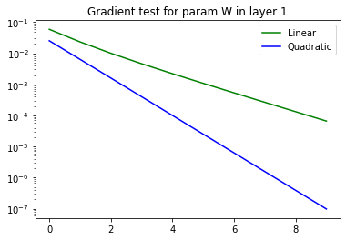

```
-----------  parameter = b ------------
Linear check should be 0.5 and is 4.78e-01
Linear check should be 0.5 and is 4.88e-01
Linear check should be 0.5 and is 4.94e-01
Linear check should be 0.5 and is 4.97e-01
Linear check should be 0.5 and is 4.98e-01
Linear check should be 0.5 and is 4.99e-01
Linear check should be 0.5 and is 5.00e-01
Linear check should be 0.5 and is 5.00e-01
Linear check should be 0.5 and is 5.00e-01
-----------------------------------------
Quadratic check should be 0.25 and is 2.55e-01
Quadratic check should be 0.25 and is 2.52e-01
Quadratic check should be 0.25 and is 2.51e-01
Quadratic check should be 0.25 and is 2.50e-01
Quadratic check should be 0.25 and is 2.50e-01
Quadratic check should be 0.25 and is 2.50e-01
Quadratic check should be 0.25 and is 2.50e-01
Quadratic check should be 0.25 and is 2.50e-01
Quadratic check should be 0.25 and is 2.50e-01
```

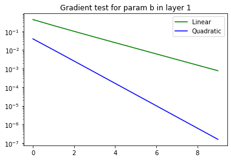

```python
data_name = 'GMMData.mat'
data_path = 'data/'
data_path = data_path + data_name
gradient_test(test_type="softmax", is_res=False, data_path=data_path, iterations=10)
```

### Qeustion 2+3:

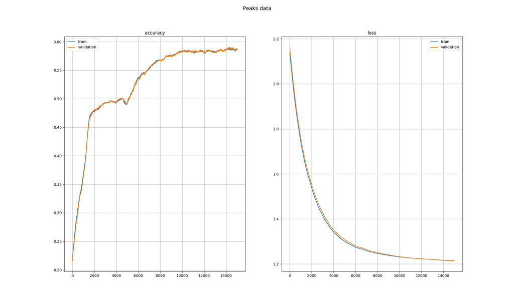

```python
from IPython.display import Image
Image('Q3/peaks.png')
```

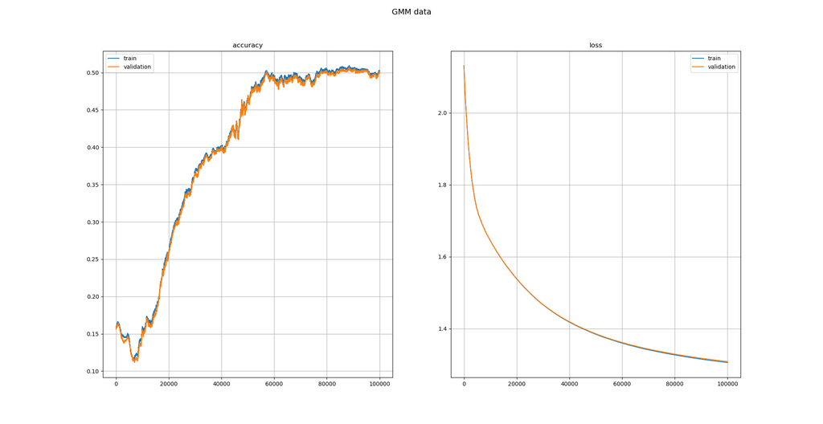

```python
Image('Q3/GMM.png')
```

### Qeustion 4:

Write the code for the standard neural network. Including the forward pass and backward pass. Run gradient tests using the tanh activation function.

### Solution:

First we show the jacobian test for the weight and bias parameters of the tanh function:

```
---------------------------  param = W  ----------------------------
should be 0.5 and is 5.34e-01
should be 0.5 and is 5.16e-01
should be 0.5 and is 5.08e-01
should be 0.5 and is 5.04e-01
should be 0.5 and is 5.02e-01
should be 0.5 and is 5.01e-01
should be 0.5 and is 5.00e-01
should be 0.5 and is 5.00e-01
should be 0.5 and is 5.00e-01
should be 0.25 and is 2.59e-01
should be 0.25 and is 2.54e-01
should be 0.25 and is 2.52e-01
should be 0.25 and is 2.51e-01
should be 0.25 and is 2.50e-01
should be 0.25 and is 2.50e-01
should be 0.25 and is 2.50e-01
should be 0.25 and is 2.50e-01
should be 0.25 and is 2.50e-01
```

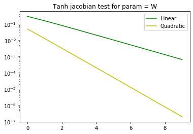

```
---------------------------  param = b  ----------------------------
should be 0.5 and is 5.31e-01
should be 0.5 and is 5.14e-01
should be 0.5 and is 5.07e-01
should be 0.5 and is 5.03e-01
should be 0.5 and is 5.02e-01
should be 0.5 and is 5.01e-01
should be 0.5 and is 5.00e-01
should be 0.5 and is 5.00e-01
should be 0.5 and is 5.00e-01
should be 0.25 and is 2.49e-01
should be 0.25 and is 2.49e-01
should be 0.25 and is 2.49e-01
should be 0.25 and is 2.50e-01
should be 0.25 and is 2.50e-01
should be 0.25 and is 2.50e-01
should be 0.25 and is 2.50e-01
should be 0.25 and is 2.50e-01
should be 0.25 and is 2.50e-01
```

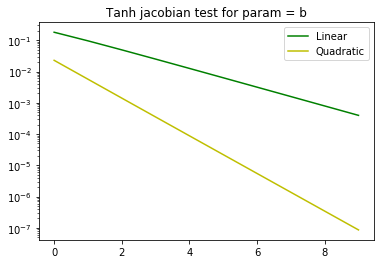

```python
jacobian_test(data_path=data_path)
```

#### Graient test:

For the gradient test we'll construct a short 2 layer network where the first layer's activation function is tanh and the second is the softmax function (which we already validated its correctness). For this simple network the hidden layer will contain 5 neurons (so the weight matrix w will be of shape (5, input_size)).  
We now show the gardient test for the tanh layer (later on we will show the classification results using the entire network):

```
-----------  parameter = W ------------
Linear check should be 0.5 and is 5.10e-01
Linear check should be 0.5 and is 5.04e-01
Linear check should be 0.5 and is 5.01e-01
Linear check should be 0.5 and is 5.01e-01
Linear check should be 0.5 and is 5.00e-01
Linear check should be 0.5 and is 5.00e-01
Linear check should be 0.5 and is 5.00e-01
Linear check should be 0.5 and is 5.00e-01
Linear check should be 0.5 and is 5.00e-01
-----------------------------------------
Quadratic check should be 0.25 and is 1.99e-01
Quadratic check should be 0.25 and is 2.17e-01
Quadratic check should be 0.25 and is 2.31e-01
Quadratic check should be 0.25 and is 2.39e-01
Quadratic check should be 0.25 and is 2.44e-01
Quadratic check should be 0.25 and is 2.47e-01
Quadratic check should be 0.25 and is 2.49e-01
Quadratic check should be 0.25 and is 2.49e-01
Quadratic check should be 0.25 and is 2.50e-01
```

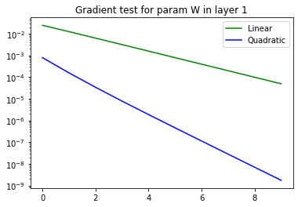

```
-----------  parameter = b ------------
Linear check should be 0.5 and is 5.73e-01
Linear check should be 0.5 and is 5.24e-01
Linear check should be 0.5 and is 5.09e-01
Linear check should be 0.5 and is 5.03e-01
Linear check should be 0.5 and is 5.02e-01
Linear check should be 0.5 and is 5.01e-01
Linear check should be 0.5 and is 5.00e-01
Linear check should be 0.5 and is 5.00e-01
Linear check should be 0.5 and is 5.00e-01
-----------------------------------------
Quadratic check should be 0.25 and is 1.94e-01
Quadratic check should be 0.25 and is 1.98e-01
Quadratic check should be 0.25 and is 2.13e-01
Quadratic check should be 0.25 and is 2.27e-01
Quadratic check should be 0.25 and is 2.37e-01
Quadratic check should be 0.25 and is 2.43e-01
Quadratic check should be 0.25 and is 2.46e-01
Quadratic check should be 0.25 and is 2.48e-01
Quadratic check should be 0.25 and is 2.49e-01
```

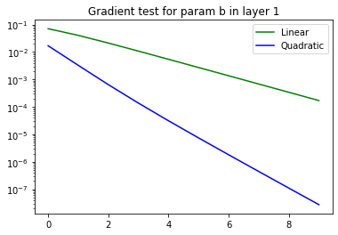

```python
gradient_test(test_type="tanh", is_res=False, data_path=data_path, iterations=10)
```

### Qeustion 5:

Repeat the previous section for the residual neural network.

### Solution:

```
---------------------------  param = W  ----------------------------
should be 0.5 and is 5.18e-01
should be 0.5 and is 5.07e-01
should be 0.5 and is 5.03e-01
should be 0.5 and is 5.01e-01
should be 0.5 and is 5.01e-01
should be 0.5 and is 5.00e-01
should be 0.5 and is 5.00e-01
should be 0.5 and is 5.00e-01
should be 0.5 and is 5.00e-01
should be 0.25 and is 2.37e-01
should be 0.25 and is 2.46e-01
should be 0.25 and is 2.49e-01
should be 0.25 and is 2.50e-01
should be 0.25 and is 2.50e-01
should be 0.25 and is 2.50e-01
should be 0.25 and is 2.50e-01
should be 0.25 and is 2.50e-01
should be 0.25 and is 2.50e-01
```

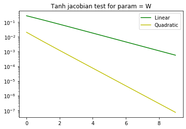

```
---------------------------  param = b  ----------------------------
should be 0.5 and is 4.96e-01
should be 0.5 and is 4.97e-01
should be 0.5 and is 4.98e-01
should be 0.5 and is 4.99e-01
should be 0.5 and is 5.00e-01
should be 0.5 and is 5.00e-01
should be 0.5 and is 5.00e-01
should be 0.5 and is 5.00e-01
should be 0.5 and is 5.00e-01
should be 0.25 and is 2.52e-01
should be 0.25 and is 2.53e-01
should be 0.25 and is 2.52e-01
should be 0.25 and is 2.51e-01
should be 0.25 and is 2.50e-01
should be 0.25 and is 2.50e-01
should be 0.25 and is 2.50e-01
should be 0.25 and is 2.50e-01
should be 0.25 and is 2.50e-01
```

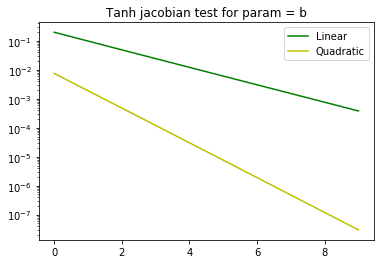

```python
is_resnet=True
jacobian_test(data_path=data_path, is_resnet=is_resnet)
```

```
-----------  parameter = W ------------
Linear check should be 0.5 and is 4.48e-01
Linear check should be 0.5 and is 4.71e-01
Linear check should be 0.5 and is 4.85e-01
Linear check should be 0.5 and is 4.92e-01
Linear check should be 0.5 and is 4.96e-01
Linear check should be 0.5 and is 4.98e-01
Linear check should be 0.5 and is 4.99e-01
Linear check should be 0.5 and is 5.00e-01
Linear check should be 0.5 and is 5.00e-01
-----------------------------------------
Quadratic check should be 0.25 and is 2.49e-01
Quadratic check should be 0.25 and is 2.48e-01
Quadratic check should be 0.25 and is 2.48e-01
Quadratic check should be 0.25 and is 2.49e-01
Quadratic check should be 0.25 and is 2.50e-01
Quadratic check should be 0.25 and is 2.50e-01
Quadratic check should be 0.25 and is 2.50e-01
Quadratic check should be 0.25 and is 2.50e-01
Quadratic check should be 0.25 and is 2.50e-01
```

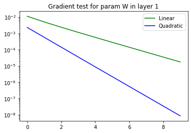

```
-----------  parameter = b ------------
Linear check should be 0.5 and is 6.55e-01
Linear check should be 0.5 and is 3.76e-01
Linear check should be 0.5 and is 3.51e-01
Linear check should be 0.5 and is 3.72e-01
Linear check should be 0.5 and is 4.07e-01
Linear check should be 0.5 and is 4.41e-01
Linear check should be 0.5 and is 4.66e-01
Linear check should be 0.5 and is 4.82e-01
Linear check should be 0.5 and is 4.90e-01
-----------------------------------------
Quadratic check should be 0.25 and is 7.28e-01
Quadratic check should be 0.25 and is 3.36e-01
Quadratic check should be 0.25 and is 2.80e-01
Quadratic check should be 0.25 and is 2.62e-01
Quadratic check should be 0.25 and is 2.56e-01
Quadratic check should be 0.25 and is 2.53e-01
Quadratic check should be 0.25 and is 2.51e-01
Quadratic check should be 0.25 and is 2.51e-01
Quadratic check should be 0.25 and is 2.50e-01
```

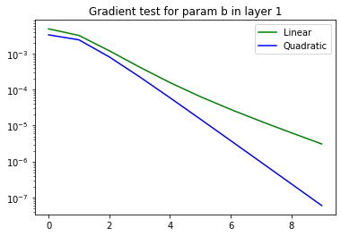

```
-----------  parameter = W2 ------------
Linear check should be 0.5 and is 4.95e-01
Linear check should be 0.5 and is 4.98e-01
Linear check should be 0.5 and is 4.99e-01
Linear check should be 0.5 and is 4.99e-01
Linear check should be 0.5 and is 5.00e-01
Linear check should be 0.5 and is 5.00e-01
Linear check should be 0.5 and is 5.00e-01
Linear check should be 0.5 and is 5.00e-01
Linear check should be 0.5 and is 5.00e-01
-----------------------------------------
Quadratic check should be 0.25 and is 2.53e-01
Quadratic check should be 0.25 and is 2.51e-01
Quadratic check should be 0.25 and is 2.51e-01
Quadratic check should be 0.25 and is 2.50e-01
Quadratic check should be 0.25 and is 2.50e-01
Quadratic check should be 0.25 and is 2.50e-01
Quadratic check should be 0.25 and is 2.50e-01
Quadratic check should be 0.25 and is 2.50e-01
Quadratic check should be 0.25 and is 2.50e-01
```

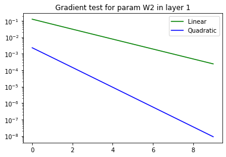

```python
gradient_test(test_type="tanh", is_res=True, data_path=data_path, iterations=10)
```

### Qeustion 6 + 7:

Compute a forward pass and a backward pass of a network with L layers (L is a parameter). See that the gradient of the whole network (softmax + layers) passes the gradient test. Submit this verification.  
Repeat section 3 for the entire network. Try a few network lengths and see how this influences the performance. Write your conclusions and demonstrate them.

### Solution:

```python
num_hidden_layers = 4

hidden_layers_size = 40
batch_size = 32
epochs = 20

network = prepare_net_and_run(data_path, hidden_layers_size, num_hidden_layers, epochs, batch_size)
```

```
shapes are X_train:(5, 25000), y_train:(25000, 5), X_val:(5, 6250), y_val:(6250, 5)
For epoch = 1, batch 0/782:
	 loss is 1.5838880486434554 and accuracy is 37.5 percent.
For epoch = 1, batch 250/782:
	 loss is 1.5950322968289645 and accuracy is 21.875 percent.
For epoch = 1, batch 500/782:
	 loss is 1.3048138990590026 and accuracy is 46.875 percent.
For epoch = 1, batch 750/782:
	 loss is 1.305896592803645 and accuracy is 50.0 percent.
For epoch = 2, batch 0/782:
	 loss is 1.2092685311650124 and accuracy is 50.0 percent.
For epoch = 2, batch 250/782:
	 loss is 1.2981739203018066 and accuracy is 28.125 percent.
For epoch = 2, batch 500/782:
	 loss is 1.1764201356429327 and accuracy is 56.25 percent.
For epoch = 2, batch 750/782:
	 loss is 1.363318756718844 and accuracy is 46.875 percent.
For epoch = 3, batch 0/782:
	 loss is 1.1971417980865717 and accuracy is 59.375 percent.
For epoch = 3, batch 250/782:
	 loss is 0.9850313030055997 and accuracy is 59.375 percent.
For epoch = 3, batch 500/782:
	 loss is 0.7968673286893515 and accuracy is 50.0 percent.
For epoch = 3, batch 750/782:
	 loss is 0.5280868151719491 and accuracy is 78.125 percent.
For epoch = 4, batch 0/782:
	 loss is 0.6042832786046914 and accuracy is 75.0 percent.
For epoch = 4, batch 250/782:
	 loss is 0.7595564120734783 and accuracy is 62.5 percent.
For epoch = 4, batch 500/782:
	 loss is 0.4948306225827897 and accuracy is 81.25 percent.
For epoch = 4, batch 750/782:
	 loss is 0.46809236227214446 and accuracy is 81.25 percent.
For epoch = 5, batch 0/782:
	 loss is 0.3779295991534789 and accuracy is 81.25 percent.
For epoch = 5, batch 250/782:
	 loss is 0.44923941070997286 and accuracy is 84.375 percent.
For epoch = 5, batch 500/782:
	 loss is 0.3781678700717332 and accuracy is 84.375 percent.
For epoch = 5, batch 750/782:
```

[output cut: 111 more lines]

```
For epoch = 19, batch 750/782:
	 loss is 0.010670456028576834 and accuracy is 100.0 percent.
For epoch = 20, batch 0/782:
	 loss is 0.0034093767012552817 and accuracy is 100.0 percent.
For epoch = 20, batch 250/782:
	 loss is 0.0049296267866425336 and accuracy is 100.0 percent.
For epoch = 20, batch 500/782:
	 loss is 0.013769084045350283 and accuracy is 100.0 percent.
For epoch = 20, batch 750/782:
	 loss is 0.0023892002189021223 and accuracy is 100.0 percent.

########################################
For the test data:
Final loss for test data is 0.019356279918142708 and accuracy is 99.408 percent.
########################################
```

Here are the graphs showing the accuracies and losses per epoch for the train (for which we show the results of the last mini-batch in every epoch) and test sets:

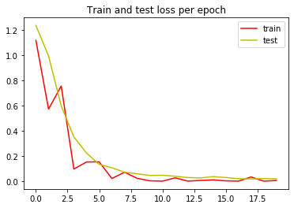

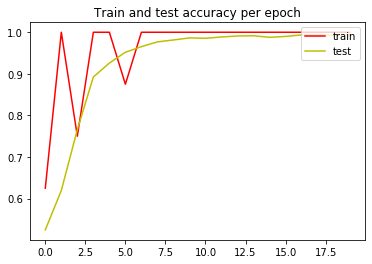

```python
network.show_epoch_performance()
```

Now we will show the gardients tests for parameters in the network's layers:

```
-----------  W  in layer 1 ------------
Linear check should be 0.5 and is 5.10e-01
Linear check should be 0.5 and is 5.04e-01
Linear check should be 0.5 and is 5.02e-01
Linear check should be 0.5 and is 5.01e-01
Linear check should be 0.5 and is 5.00e-01
Linear check should be 0.5 and is 5.00e-01
Linear check should be 0.5 and is 5.00e-01
Linear check should be 0.5 and is 5.00e-01
Linear check should be 0.5 and is 5.00e-01
-----------------------------------------
Quadratic check should be 0.25 and is 2.02e-01
Quadratic check should be 0.25 and is 2.19e-01
Quadratic check should be 0.25 and is 2.32e-01
Quadratic check should be 0.25 and is 2.40e-01
Quadratic check should be 0.25 and is 2.45e-01
Quadratic check should be 0.25 and is 2.47e-01
Quadratic check should be 0.25 and is 2.49e-01
Quadratic check should be 0.25 and is 2.49e-01
Quadratic check should be 0.25 and is 2.50e-01
```

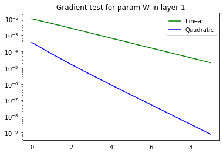

```
-----------  b  in layer 1 ------------
Linear check should be 0.5 and is 5.14e-01
Linear check should be 0.5 and is 5.05e-01
Linear check should be 0.5 and is 5.02e-01
Linear check should be 0.5 and is 5.01e-01
Linear check should be 0.5 and is 5.00e-01
Linear check should be 0.5 and is 5.00e-01
Linear check should be 0.5 and is 5.00e-01
Linear check should be 0.5 and is 5.00e-01
Linear check should be 0.5 and is 5.00e-01
-----------------------------------------
Quadratic check should be 0.25 and is 1.97e-01
Quadratic check should be 0.25 and is 2.15e-01
Quadratic check should be 0.25 and is 2.29e-01
Quadratic check should be 0.25 and is 2.39e-01
Quadratic check should be 0.25 and is 2.44e-01
Quadratic check should be 0.25 and is 2.47e-01
Quadratic check should be 0.25 and is 2.48e-01
Quadratic check should be 0.25 and is 2.49e-01
Quadratic check should be 0.25 and is 2.50e-01
```

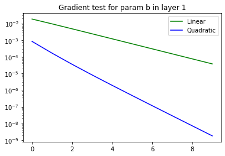

```
-----------  W  in layer 2 ------------
Linear check should be 0.5 and is 5.01e-01
Linear check should be 0.5 and is 5.00e-01
Linear check should be 0.5 and is 5.00e-01
Linear check should be 0.5 and is 5.00e-01
Linear check should be 0.5 and is 5.00e-01
Linear check should be 0.5 and is 5.00e-01
Linear check should be 0.5 and is 5.00e-01
Linear check should be 0.5 and is 5.00e-01
Linear check should be 0.5 and is 5.00e-01
-----------------------------------------
Quadratic check should be 0.25 and is 1.23e-01
Quadratic check should be 0.25 and is 1.20e-01
Quadratic check should be 0.25 and is 1.14e-01
Quadratic check should be 0.25 and is 1.01e-01
Quadratic check should be 0.25 and is 6.62e-02
Quadratic check should be 0.25 and is 9.75e-02
Quadratic check should be 0.25 and is 6.96e-01
Quadratic check should be 0.25 and is 3.30e-01
Quadratic check should be 0.25 and is 2.80e-01
```

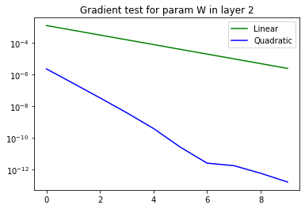

```
-----------  b  in layer 2 ------------
Linear check should be 0.5 and is 5.11e-01
Linear check should be 0.5 and is 5.05e-01
Linear check should be 0.5 and is 5.02e-01
Linear check should be 0.5 and is 5.01e-01
Linear check should be 0.5 and is 5.00e-01
Linear check should be 0.5 and is 5.00e-01
Linear check should be 0.5 and is 5.00e-01
Linear check should be 0.5 and is 5.00e-01
Linear check should be 0.5 and is 5.00e-01
-----------------------------------------
Quadratic check should be 0.25 and is 2.17e-01
Quadratic check should be 0.25 and is 2.24e-01
Quadratic check should be 0.25 and is 2.33e-01
Quadratic check should be 0.25 and is 2.41e-01
Quadratic check should be 0.25 and is 2.45e-01
Quadratic check should be 0.25 and is 2.47e-01
Quadratic check should be 0.25 and is 2.49e-01
Quadratic check should be 0.25 and is 2.49e-01
Quadratic check should be 0.25 and is 2.50e-01
```

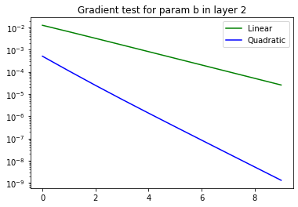

```
-----------  W  in layer 3 ------------
Linear check should be 0.5 and is 4.95e-01
Linear check should be 0.5 and is 4.97e-01
Linear check should be 0.5 and is 4.99e-01
Linear check should be 0.5 and is 4.99e-01
Linear check should be 0.5 and is 5.00e-01
Linear check should be 0.5 and is 5.00e-01
Linear check should be 0.5 and is 5.00e-01
Linear check should be 0.5 and is 5.00e-01
Linear check should be 0.5 and is 5.00e-01
-----------------------------------------
Quadratic check should be 0.25 and is 2.57e-01
Quadratic check should be 0.25 and is 2.53e-01
Quadratic check should be 0.25 and is 2.52e-01
Quadratic check should be 0.25 and is 2.51e-01
Quadratic check should be 0.25 and is 2.50e-01
Quadratic check should be 0.25 and is 2.50e-01
Quadratic check should be 0.25 and is 2.50e-01
Quadratic check should be 0.25 and is 2.50e-01
Quadratic check should be 0.25 and is 2.50e-01
```

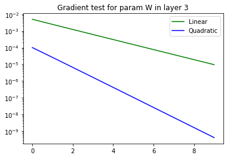

```
-----------  b  in layer 3 ------------
Linear check should be 0.5 and is 5.50e-01
Linear check should be 0.5 and is 5.24e-01
Linear check should be 0.5 and is 5.12e-01
Linear check should be 0.5 and is 5.06e-01
Linear check should be 0.5 and is 5.03e-01
Linear check should be 0.5 and is 5.01e-01
Linear check should be 0.5 and is 5.01e-01
Linear check should be 0.5 and is 5.00e-01
Linear check should be 0.5 and is 5.00e-01
-----------------------------------------
Quadratic check should be 0.25 and is 2.60e-01
Quadratic check should be 0.25 and is 2.49e-01
Quadratic check should be 0.25 and is 2.48e-01
Quadratic check should be 0.25 and is 2.49e-01
Quadratic check should be 0.25 and is 2.49e-01
Quadratic check should be 0.25 and is 2.50e-01
Quadratic check should be 0.25 and is 2.50e-01
Quadratic check should be 0.25 and is 2.50e-01
Quadratic check should be 0.25 and is 2.50e-01
```

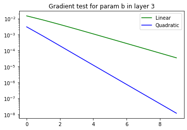

```
-----------  W  in layer 4 ------------
Linear check should be 0.5 and is 5.01e-01
Linear check should be 0.5 and is 5.01e-01
Linear check should be 0.5 and is 5.00e-01
Linear check should be 0.5 and is 5.00e-01
Linear check should be 0.5 and is 5.00e-01
Linear check should be 0.5 and is 5.00e-01
Linear check should be 0.5 and is 5.00e-01
Linear check should be 0.5 and is 5.00e-01
Linear check should be 0.5 and is 5.00e-01
-----------------------------------------
Quadratic check should be 0.25 and is 2.52e-01
Quadratic check should be 0.25 and is 2.51e-01
Quadratic check should be 0.25 and is 2.50e-01
Quadratic check should be 0.25 and is 2.50e-01
Quadratic check should be 0.25 and is 2.50e-01
Quadratic check should be 0.25 and is 2.50e-01
Quadratic check should be 0.25 and is 2.50e-01
Quadratic check should be 0.25 and is 2.50e-01
Quadratic check should be 0.25 and is 2.50e-01
```

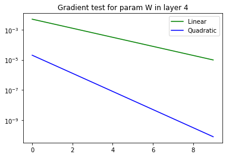

```
-----------  b  in layer 4 ------------
Linear check should be 0.5 and is 4.89e-01
Linear check should be 0.5 and is 4.93e-01
Linear check should be 0.5 and is 4.96e-01
Linear check should be 0.5 and is 4.98e-01
Linear check should be 0.5 and is 4.99e-01
Linear check should be 0.5 and is 4.99e-01
Linear check should be 0.5 and is 5.00e-01
Linear check should be 0.5 and is 5.00e-01
Linear check should be 0.5 and is 5.00e-01
-----------------------------------------
Quadratic check should be 0.25 and is 2.92e-01
Quadratic check should be 0.25 and is 2.64e-01
Quadratic check should be 0.25 and is 2.56e-01
Quadratic check should be 0.25 and is 2.52e-01
Quadratic check should be 0.25 and is 2.51e-01
Quadratic check should be 0.25 and is 2.51e-01
Quadratic check should be 0.25 and is 2.50e-01
Quadratic check should be 0.25 and is 2.50e-01
Quadratic check should be 0.25 and is 2.50e-01
```

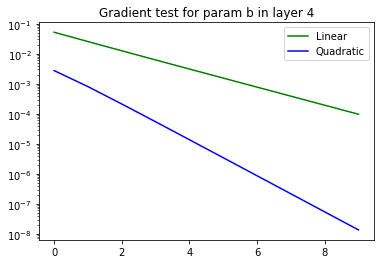

```
-----------  W  in layer 5 ------------
Linear check should be 0.5 and is 4.92e-01
Linear check should be 0.5 and is 4.96e-01
Linear check should be 0.5 and is 4.98e-01
Linear check should be 0.5 and is 4.99e-01
Linear check should be 0.5 and is 4.99e-01
Linear check should be 0.5 and is 5.00e-01
Linear check should be 0.5 and is 5.00e-01
Linear check should be 0.5 and is 5.00e-01
Linear check should be 0.5 and is 5.00e-01
-----------------------------------------
Quadratic check should be 0.25 and is 2.51e-01
Quadratic check should be 0.25 and is 2.51e-01
Quadratic check should be 0.25 and is 2.50e-01
Quadratic check should be 0.25 and is 2.50e-01
Quadratic check should be 0.25 and is 2.50e-01
Quadratic check should be 0.25 and is 2.50e-01
Quadratic check should be 0.25 and is 2.50e-01
Quadratic check should be 0.25 and is 2.50e-01
Quadratic check should be 0.25 and is 2.50e-01
```

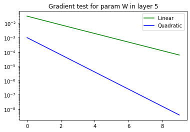

```
-----------  b  in layer 5 ------------
Linear check should be 0.5 and is 4.17e-01
Linear check should be 0.5 and is 4.42e-01
Linear check should be 0.5 and is 4.65e-01
Linear check should be 0.5 and is 4.80e-01
Linear check should be 0.5 and is 4.90e-01
Linear check should be 0.5 and is 4.95e-01
Linear check should be 0.5 and is 4.97e-01
Linear check should be 0.5 and is 4.99e-01
Linear check should be 0.5 and is 4.99e-01
-----------------------------------------
Quadratic check should be 0.25 and is 2.74e-01
Quadratic check should be 0.25 and is 2.62e-01
Quadratic check should be 0.25 and is 2.56e-01
Quadratic check should be 0.25 and is 2.53e-01
Quadratic check should be 0.25 and is 2.51e-01
Quadratic check should be 0.25 and is 2.51e-01
Quadratic check should be 0.25 and is 2.50e-01
Quadratic check should be 0.25 and is 2.50e-01
Quadratic check should be 0.25 and is 2.50e-01
```

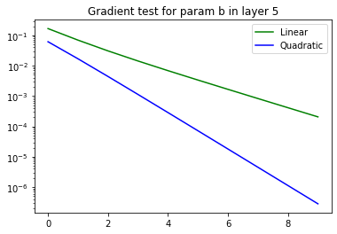

```python
gradient_test(test_type="network", is_res=False, data_path=data_path, iterations=10, num_hidden_layers=num_hidden_layers, hidden_layers_size=hidden_layers_size)
```

### Playing with the parameters:

Now we will play around a bit with the parameters.  
Recall that our above baseline is reached using 5 layers (4 hidden) and 40 neurons per hidden layer.

70 neurons per hidden layer (99.55% accuarcy):

```python
hidden_layers_size = 70

network = prepare_net_and_run(data_path, hidden_layers_size, num_hidden_layers, epochs, batch_size)
```

```
shapes are X_train:(5, 25000), y_train:(25000, 5), X_val:(5, 6250), y_val:(6250, 5)
For epoch = 1, batch 0/782:
	 loss is 1.6012689469419086 and accuracy is 15.625 percent.
For epoch = 1, batch 250/782:
	 loss is 1.2666264907596467 and accuracy is 43.75 percent.
For epoch = 1, batch 500/782:
	 loss is 1.1193245566243664 and accuracy is 62.5 percent.
For epoch = 1, batch 750/782:
	 loss is 1.0782723185095053 and accuracy is 56.25 percent.
For epoch = 2, batch 0/782:
	 loss is 1.2923546224235178 and accuracy is 59.375 percent.
For epoch = 2, batch 250/782:
	 loss is 1.0398365750259095 and accuracy is 56.25 percent.
For epoch = 2, batch 500/782:
	 loss is 0.7812700216403805 and accuracy is 71.875 percent.
For epoch = 2, batch 750/782:
	 loss is 0.5787754957967279 and accuracy is 84.375 percent.
For epoch = 3, batch 0/782:
	 loss is 0.44137700230471777 and accuracy is 87.5 percent.
For epoch = 3, batch 250/782:
	 loss is 0.6322035072126573 and accuracy is 75.0 percent.
For epoch = 3, batch 500/782:
	 loss is 0.43117988773644267 and accuracy is 90.625 percent.
For epoch = 3, batch 750/782:
	 loss is 0.34760344597068 and accuracy is 90.625 percent.
For epoch = 4, batch 0/782:
	 loss is 0.4196837698867447 and accuracy is 84.375 percent.
For epoch = 4, batch 250/782:
	 loss is 0.25615181165115847 and accuracy is 87.5 percent.
For epoch = 4, batch 500/782:
	 loss is 0.34177102990173336 and accuracy is 90.625 percent.
For epoch = 4, batch 750/782:
	 loss is 0.06932622529430535 and accuracy is 100.0 percent.
For epoch = 5, batch 0/782:
	 loss is 0.29569355206162345 and accuracy is 90.625 percent.
For epoch = 5, batch 250/782:
	 loss is 0.04124066190321276 and accuracy is 100.0 percent.
For epoch = 5, batch 500/782:
	 loss is 0.09966506736834863 and accuracy is 96.875 percent.
For epoch = 5, batch 750/782:
```

[output cut: 111 more lines]

```
For epoch = 19, batch 750/782:
	 loss is 0.01654658452399809 and accuracy is 100.0 percent.
For epoch = 20, batch 0/782:
	 loss is 0.004291694360882867 and accuracy is 100.0 percent.
For epoch = 20, batch 250/782:
	 loss is 0.006076895088164365 and accuracy is 100.0 percent.
For epoch = 20, batch 500/782:
	 loss is 0.017961530086547453 and accuracy is 100.0 percent.
For epoch = 20, batch 750/782:
	 loss is 0.0004539713662132427 and accuracy is 100.0 percent.

########################################
For the test data:
Final loss for test data is 0.014884919422041537 and accuracy is 99.55199999999999 percent.
########################################
```

100 neurons per hidden layer (99.58% accuarcy):

```python
hidden_layers_size = 100

network = prepare_net_and_run(data_path, hidden_layers_size, num_hidden_layers, epochs, batch_size)
```

```
shapes are X_train:(5, 25000), y_train:(25000, 5), X_val:(5, 6250), y_val:(6250, 5)
For epoch = 1, batch 0/782:
	 loss is 1.7067195258204442 and accuracy is 12.5 percent.
For epoch = 1, batch 250/782:
	 loss is 0.9433836832900213 and accuracy is 62.5 percent.
For epoch = 1, batch 500/782:
	 loss is 1.1649852810082284 and accuracy is 62.5 percent.
For epoch = 1, batch 750/782:
	 loss is 0.9944010848713605 and accuracy is 68.75 percent.
For epoch = 2, batch 0/782:
	 loss is 0.9162302244834272 and accuracy is 65.625 percent.
For epoch = 2, batch 250/782:
	 loss is 0.6998954979639547 and accuracy is 68.75 percent.
For epoch = 2, batch 500/782:
	 loss is 0.6155517003429278 and accuracy is 78.125 percent.
For epoch = 2, batch 750/782:
	 loss is 0.2519959328291663 and accuracy is 93.75 percent.
For epoch = 3, batch 0/782:
	 loss is 0.20444867404522055 and accuracy is 96.875 percent.
For epoch = 3, batch 250/782:
	 loss is 0.136563002945626 and accuracy is 96.875 percent.
For epoch = 3, batch 500/782:
	 loss is 0.1525307212954683 and accuracy is 93.75 percent.
For epoch = 3, batch 750/782:
	 loss is 0.23799113734356137 and accuracy is 90.625 percent.
For epoch = 4, batch 0/782:
	 loss is 0.09173525916970174 and accuracy is 96.875 percent.
For epoch = 4, batch 250/782:
	 loss is 0.19566811661283035 and accuracy is 96.875 percent.
For epoch = 4, batch 500/782:
	 loss is 0.05654919181552163 and accuracy is 96.875 percent.
For epoch = 4, batch 750/782:
	 loss is 0.035384004599511465 and accuracy is 100.0 percent.
For epoch = 5, batch 0/782:
	 loss is 0.043880461375308474 and accuracy is 96.875 percent.
For epoch = 5, batch 250/782:
	 loss is 0.032821201197645075 and accuracy is 100.0 percent.
For epoch = 5, batch 500/782:
	 loss is 0.009394099340407554 and accuracy is 100.0 percent.
For epoch = 5, batch 750/782:
```

[output cut: 111 more lines]

```
For epoch = 19, batch 750/782:
	 loss is 0.0038831737908801723 and accuracy is 100.0 percent.
For epoch = 20, batch 0/782:
	 loss is 0.0026368079490500353 and accuracy is 100.0 percent.
For epoch = 20, batch 250/782:
	 loss is 0.018540723067213934 and accuracy is 100.0 percent.
For epoch = 20, batch 500/782:
	 loss is 0.0029052396262641634 and accuracy is 100.0 percent.
For epoch = 20, batch 750/782:
	 loss is 0.0014482404837938515 and accuracy is 100.0 percent.

########################################
For the test data:
Final loss for test data is 0.013885543267138825 and accuracy is 99.58399999999999 percent.
########################################
```

10 neurons per hidden layer (97.8% accuarcy):

```python
hidden_layers_size = 10

network = prepare_net_and_run(data_path, hidden_layers_size, num_hidden_layers, epochs, batch_size)
```

```
shapes are X_train:(5, 25000), y_train:(25000, 5), X_val:(5, 6250), y_val:(6250, 5)
For epoch = 1, batch 0/782:
	 loss is 1.6168547212356672 and accuracy is 18.75 percent.
For epoch = 1, batch 250/782:
	 loss is 1.6112882952493397 and accuracy is 15.625 percent.
For epoch = 1, batch 500/782:
	 loss is 1.609514295770203 and accuracy is 21.875 percent.
For epoch = 1, batch 750/782:
	 loss is 1.6096467167948114 and accuracy is 18.75 percent.
For epoch = 2, batch 0/782:
	 loss is 1.6096624446391155 and accuracy is 9.375 percent.
For epoch = 2, batch 250/782:
	 loss is 1.6097174132483487 and accuracy is 18.75 percent.
For epoch = 2, batch 500/782:
	 loss is 1.610884447464016 and accuracy is 18.75 percent.
For epoch = 2, batch 750/782:
	 loss is 1.6049119218407246 and accuracy is 25.0 percent.
For epoch = 3, batch 0/782:
	 loss is 1.6067007105934445 and accuracy is 31.25 percent.
For epoch = 3, batch 250/782:
	 loss is 1.602683650197691 and accuracy is 31.25 percent.
For epoch = 3, batch 500/782:
	 loss is 1.6076631527787193 and accuracy is 25.0 percent.
For epoch = 3, batch 750/782:
	 loss is 1.617138480667156 and accuracy is 12.5 percent.
For epoch = 4, batch 0/782:
	 loss is 1.6184607389066406 and accuracy is 6.25 percent.
For epoch = 4, batch 250/782:
	 loss is 1.6084770573311968 and accuracy is 21.875 percent.
For epoch = 4, batch 500/782:
	 loss is 1.6129876228285671 and accuracy is 21.875 percent.
For epoch = 4, batch 750/782:
	 loss is 1.6197473820710426 and accuracy is 12.5 percent.
For epoch = 5, batch 0/782:
	 loss is 1.6089079830681938 and accuracy is 21.875 percent.
For epoch = 5, batch 250/782:
	 loss is 1.6073685969338933 and accuracy is 21.875 percent.
For epoch = 5, batch 500/782:
	 loss is 1.5960133221995085 and accuracy is 28.125 percent.
For epoch = 5, batch 750/782:
```

[output cut: 111 more lines]

```
For epoch = 19, batch 750/782:
	 loss is 0.11673673887747847 and accuracy is 93.75 percent.
For epoch = 20, batch 0/782:
	 loss is 0.24928099115293345 and accuracy is 87.5 percent.
For epoch = 20, batch 250/782:
	 loss is 0.09399503982711564 and accuracy is 100.0 percent.
For epoch = 20, batch 500/782:
	 loss is 0.11195921897080721 and accuracy is 96.875 percent.
For epoch = 20, batch 750/782:
	 loss is 0.051954111071493565 and accuracy is 100.0 percent.

########################################
For the test data:
Final loss for test data is 0.07928823079901236 and accuracy is 97.872 percent.
########################################
```

5 neurons per hidden layer (45.6% accuarcy):

```python
hidden_layers_size = 5

network = prepare_net_and_run(data_path, hidden_layers_size, num_hidden_layers, epochs, batch_size)
```

```
shapes are X_train:(5, 25000), y_train:(25000, 5), X_val:(5, 6250), y_val:(6250, 5)
For epoch = 1, batch 0/782:
	 loss is 1.6131638942336437 and accuracy is 18.75 percent.
For epoch = 1, batch 250/782:
	 loss is 1.6091302951619346 and accuracy is 28.125 percent.
For epoch = 1, batch 500/782:
	 loss is 1.6099964600157808 and accuracy is 15.625 percent.
For epoch = 1, batch 750/782:
	 loss is 1.6093051109973793 and accuracy is 3.125 percent.
For epoch = 2, batch 0/782:
	 loss is 1.609609423643232 and accuracy is 12.5 percent.
For epoch = 2, batch 250/782:
	 loss is 1.612186650890884 and accuracy is 12.5 percent.
For epoch = 2, batch 500/782:
	 loss is 1.6132311561509673 and accuracy is 18.75 percent.
For epoch = 2, batch 750/782:
	 loss is 1.6139725531564462 and accuracy is 9.375 percent.
For epoch = 3, batch 0/782:
	 loss is 1.602817096137186 and accuracy is 25.0 percent.
For epoch = 3, batch 250/782:
	 loss is 1.609539578642675 and accuracy is 21.875 percent.
For epoch = 3, batch 500/782:
	 loss is 1.6062530104320378 and accuracy is 28.125 percent.
For epoch = 3, batch 750/782:
	 loss is 1.6128591917789206 and accuracy is 12.5 percent.
For epoch = 4, batch 0/782:
	 loss is 1.6045340533066614 and accuracy is 31.25 percent.
For epoch = 4, batch 250/782:
	 loss is 1.6115946899861326 and accuracy is 25.0 percent.
For epoch = 4, batch 500/782:
	 loss is 1.6050427394148414 and accuracy is 34.375 percent.
For epoch = 4, batch 750/782:
	 loss is 1.610646166251081 and accuracy is 12.5 percent.
For epoch = 5, batch 0/782:
	 loss is 1.608387049239941 and accuracy is 25.0 percent.
For epoch = 5, batch 250/782:
	 loss is 1.6063937936429336 and accuracy is 31.25 percent.
For epoch = 5, batch 500/782:
	 loss is 1.6080244145092637 and accuracy is 6.25 percent.
For epoch = 5, batch 750/782:
```

[output cut: 111 more lines]

```
For epoch = 19, batch 750/782:
	 loss is 1.2931052600948325 and accuracy is 46.875 percent.
For epoch = 20, batch 0/782:
	 loss is 1.2135263910936642 and accuracy is 50.0 percent.
For epoch = 20, batch 250/782:
	 loss is 1.3013436260156819 and accuracy is 40.625 percent.
For epoch = 20, batch 500/782:
	 loss is 1.228908492179825 and accuracy is 50.0 percent.
For epoch = 20, batch 750/782:
	 loss is 1.37677713410796 and accuracy is 34.375 percent.

########################################
For the test data:
Final loss for test data is 1.2401774149936873 and accuracy is 45.6 percent.
########################################
```

10 layers (99.4% accuracy):

```python
num_hidden_layers = 9

network = prepare_net_and_run(data_path, hidden_layers_size, num_hidden_layers, epochs, batch_size)
```

```
shapes are X_train:(5, 25000), y_train:(25000, 5), X_val:(5, 6250), y_val:(6250, 5)
For epoch = 1, batch 0/782:
	 loss is 1.6809958078692253 and accuracy is 6.25 percent.
For epoch = 1, batch 250/782:
	 loss is 1.605078885831411 and accuracy is 18.75 percent.
For epoch = 1, batch 500/782:
	 loss is 1.6067371413319271 and accuracy is 21.875 percent.
For epoch = 1, batch 750/782:
	 loss is 1.6144531244062394 and accuracy is 18.75 percent.
For epoch = 2, batch 0/782:
	 loss is 1.6082355674272941 and accuracy is 25.0 percent.
For epoch = 2, batch 250/782:
	 loss is 1.6000532330694899 and accuracy is 31.25 percent.
For epoch = 2, batch 500/782:
	 loss is 1.580992905351236 and accuracy is 34.375 percent.
For epoch = 2, batch 750/782:
	 loss is 1.3344204269226652 and accuracy is 43.75 percent.
For epoch = 3, batch 0/782:
	 loss is 1.1535223611435903 and accuracy is 53.125 percent.
For epoch = 3, batch 250/782:
	 loss is 1.3544263402725591 and accuracy is 28.125 percent.
For epoch = 3, batch 500/782:
	 loss is 1.2167480488866786 and accuracy is 46.875 percent.
For epoch = 3, batch 750/782:
	 loss is 1.2608712742582993 and accuracy is 37.5 percent.
For epoch = 4, batch 0/782:
	 loss is 1.1771699105100335 and accuracy is 56.25 percent.
For epoch = 4, batch 250/782:
	 loss is 1.1664211827467397 and accuracy is 50.0 percent.
For epoch = 4, batch 500/782:
	 loss is 0.9819770102912173 and accuracy is 62.5 percent.
For epoch = 4, batch 750/782:
	 loss is 0.8366788970237468 and accuracy is 71.875 percent.
For epoch = 5, batch 0/782:
	 loss is 1.0076102868236738 and accuracy is 65.625 percent.
For epoch = 5, batch 250/782:
	 loss is 0.9645771921553478 and accuracy is 59.375 percent.
For epoch = 5, batch 500/782:
	 loss is 0.9372250619395712 and accuracy is 65.625 percent.
For epoch = 5, batch 750/782:
```

[output cut: 111 more lines]

```
For epoch = 19, batch 750/782:
	 loss is 0.004089774832896539 and accuracy is 100.0 percent.
For epoch = 20, batch 0/782:
	 loss is 0.0018101659810559607 and accuracy is 100.0 percent.
For epoch = 20, batch 250/782:
	 loss is 0.004072701213171008 and accuracy is 100.0 percent.
For epoch = 20, batch 500/782:
	 loss is 0.09856673891782586 and accuracy is 96.875 percent.
For epoch = 20, batch 750/782:
	 loss is 0.007345879993927862 and accuracy is 100.0 percent.

########################################
For the test data:
Final loss for test data is 0.019435733164689398 and accuracy is 99.392 percent.
########################################
```

reseting the parameter values.

```python
num_hidden_layers = 4

hidden_layers_size = 40
batch_size = 32
epochs = 20
```

#### Very deep network performance

We will now show results for deeper networks. As we can see, deeper is not always better..

15 layers:

```python
num_hidden_layers = 14
network = prepare_net_and_run(data_path, hidden_layers_size, num_hidden_layers, epochs, batch_size)
```

```
shapes are X_train:(5, 25000), y_train:(25000, 5), X_val:(5, 6250), y_val:(6250, 5)
For epoch = 1, batch 0/782:
	 loss is 1.6244638340445379 and accuracy is 12.5 percent.
For epoch = 1, batch 250/782:
	 loss is 1.609049568844091 and accuracy is 21.875 percent.
For epoch = 1, batch 500/782:
	 loss is 1.6061436730950636 and accuracy is 18.75 percent.
For epoch = 1, batch 750/782:
	 loss is 1.6123211011415077 and accuracy is 31.25 percent.
For epoch = 2, batch 0/782:
	 loss is 1.6193594218713796 and accuracy is 12.5 percent.
For epoch = 2, batch 250/782:
	 loss is 1.6128553972816635 and accuracy is 9.375 percent.
For epoch = 2, batch 500/782:
	 loss is 1.6135971335746246 and accuracy is 21.875 percent.
For epoch = 2, batch 750/782:
	 loss is 1.6018694637446766 and accuracy is 18.75 percent.
For epoch = 3, batch 0/782:
	 loss is 1.6022418618266485 and accuracy is 31.25 percent.
For epoch = 3, batch 250/782:
	 loss is 1.6160747604303598 and accuracy is 18.75 percent.
For epoch = 3, batch 500/782:
	 loss is 1.60883017381986 and accuracy is 40.625 percent.
For epoch = 3, batch 750/782:
	 loss is 1.620296717739436 and accuracy is 12.5 percent.
For epoch = 4, batch 0/782:
	 loss is 1.6129113580000591 and accuracy is 25.0 percent.
For epoch = 4, batch 250/782:
	 loss is 1.601761334103448 and accuracy is 34.375 percent.
For epoch = 4, batch 500/782:
	 loss is 1.6066779064015626 and accuracy is 25.0 percent.
For epoch = 4, batch 750/782:
	 loss is 1.6124657270550542 and accuracy is 21.875 percent.
For epoch = 5, batch 0/782:
	 loss is 1.5995892554654463 and accuracy is 34.375 percent.
For epoch = 5, batch 250/782:
	 loss is 1.609463094804392 and accuracy is 18.75 percent.
For epoch = 5, batch 500/782:
	 loss is 1.6062155317503488 and accuracy is 25.0 percent.
For epoch = 5, batch 750/782:
```

[output cut: 111 more lines]

```
For epoch = 19, batch 750/782:
	 loss is 0.9332121632261048 and accuracy is 56.25 percent.
For epoch = 20, batch 0/782:
	 loss is 1.127300342910503 and accuracy is 37.5 percent.
For epoch = 20, batch 250/782:
	 loss is 1.0841931397990416 and accuracy is 46.875 percent.
For epoch = 20, batch 500/782:
	 loss is 0.8665276524849015 and accuracy is 62.5 percent.
For epoch = 20, batch 750/782:
	 loss is 1.0784921820056208 and accuracy is 56.25 percent.

########################################
For the test data:
Final loss for test data is 0.9118448177233484 and accuracy is 60.160000000000004 percent.
########################################
```

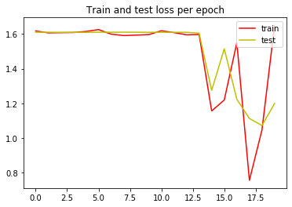

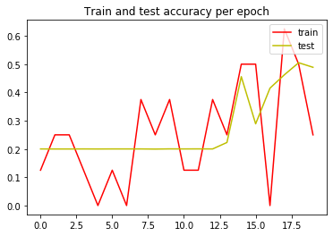

```python
network.show_epoch_performance()
```

20 layers:

```python
num_hidden_layers = 19
network = prepare_net_and_run(data_path, hidden_layers_size, num_hidden_layers, epochs, batch_size)
```

```
shapes are X_train:(5, 25000), y_train:(25000, 5), X_val:(5, 6250), y_val:(6250, 5)
For epoch = 1, batch 0/782:
	 loss is 1.6350960335547562 and accuracy is 15.625 percent.
For epoch = 1, batch 250/782:
	 loss is 1.6208818430175596 and accuracy is 12.5 percent.
For epoch = 1, batch 500/782:
	 loss is 1.6086158427036725 and accuracy is 25.0 percent.
For epoch = 1, batch 750/782:
	 loss is 1.6155007648360584 and accuracy is 12.5 percent.
For epoch = 2, batch 0/782:
	 loss is 1.608485258504845 and accuracy is 21.875 percent.
For epoch = 2, batch 250/782:
	 loss is 1.6198393251827972 and accuracy is 15.625 percent.
For epoch = 2, batch 500/782:
	 loss is 1.6116671300577934 and accuracy is 15.625 percent.
For epoch = 2, batch 750/782:
	 loss is 1.6082469217894153 and accuracy is 21.875 percent.
For epoch = 3, batch 0/782:
	 loss is 1.6003009348031971 and accuracy is 31.25 percent.
For epoch = 3, batch 250/782:
	 loss is 1.6057165322509932 and accuracy is 28.125 percent.
For epoch = 3, batch 500/782:
	 loss is 1.6149358717647733 and accuracy is 12.5 percent.
For epoch = 3, batch 750/782:
	 loss is 1.6057162877439972 and accuracy is 28.125 percent.
For epoch = 4, batch 0/782:
	 loss is 1.6190717859483486 and accuracy is 12.5 percent.
For epoch = 4, batch 250/782:
	 loss is 1.6098211963357039 and accuracy is 18.75 percent.
For epoch = 4, batch 500/782:
	 loss is 1.612039754649445 and accuracy is 15.625 percent.
For epoch = 4, batch 750/782:
	 loss is 1.6079457715620973 and accuracy is 21.875 percent.
For epoch = 5, batch 0/782:
	 loss is 1.6093073205433095 and accuracy is 18.75 percent.
For epoch = 5, batch 250/782:
	 loss is 1.6163785192968392 and accuracy is 3.125 percent.
For epoch = 5, batch 500/782:
	 loss is 1.6009901982044612 and accuracy is 28.125 percent.
For epoch = 5, batch 750/782:
```

[output cut: 111 more lines]

```
For epoch = 19, batch 750/782:
	 loss is 1.620014020665059 and accuracy is 12.5 percent.
For epoch = 20, batch 0/782:
	 loss is 1.6082758521275744 and accuracy is 28.125 percent.
For epoch = 20, batch 250/782:
	 loss is 1.607122097615917 and accuracy is 25.0 percent.
For epoch = 20, batch 500/782:
	 loss is 1.6128369753418825 and accuracy is 6.25 percent.
For epoch = 20, batch 750/782:
	 loss is 1.5876617153640529 and accuracy is 40.625 percent.

########################################
For the test data:
Final loss for test data is 1.6100893388584596 and accuracy is 20.032 percent.
########################################
```

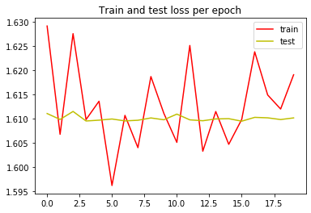

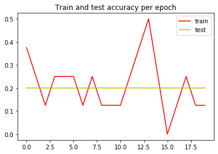

```python
network.show_epoch_performance()
```

### Qeustion 10:

If you opt to include the residual network in your code - compare between the optimization process of a standard network and a network that most of its steps are residual steps. Use about 10-20 steps in your network, and use similar vector sizes between the two options.

### Solution:

We will now run again the above network with 15 and 20 layers, only this time we will use residual layers. As can be seen, these help the network keep learning and not get stuck in a bad location early on.

15 layers:

```python
num_hidden_layers = 14
is_resnet=True
network = prepare_net_and_run(data_path, hidden_layers_size, num_hidden_layers, epochs, batch_size,  is_resnet=is_resnet)
```

```
shapes are X_train:(5, 25000), y_train:(25000, 5), X_val:(5, 6250), y_val:(6250, 5)
For epoch = 1, batch 0/782:
	 loss is 1.6441272154726252 and accuracy is 21.875 percent.
For epoch = 1, batch 250/782:
	 loss is 0.9384156282964671 and accuracy is 71.875 percent.
For epoch = 1, batch 500/782:
	 loss is 0.8073611878267283 and accuracy is 71.875 percent.
For epoch = 1, batch 750/782:
	 loss is 0.9524637348991473 and accuracy is 59.375 percent.
For epoch = 2, batch 0/782:
	 loss is 0.6806574689185543 and accuracy is 62.5 percent.
For epoch = 2, batch 250/782:
	 loss is 0.3293049409736815 and accuracy is 93.75 percent.
For epoch = 2, batch 500/782:
	 loss is 0.5369698738371651 and accuracy is 84.375 percent.
For epoch = 2, batch 750/782:
	 loss is 0.20203414556879212 and accuracy is 100.0 percent.
For epoch = 3, batch 0/782:
	 loss is 0.10428227519878579 and accuracy is 96.875 percent.
For epoch = 3, batch 250/782:
	 loss is 0.37864894845177327 and accuracy is 90.625 percent.
For epoch = 3, batch 500/782:
	 loss is 0.03060661921774091 and accuracy is 100.0 percent.
For epoch = 3, batch 750/782:
	 loss is 0.1249689986179946 and accuracy is 93.75 percent.
For epoch = 4, batch 0/782:
	 loss is 0.015265480986713638 and accuracy is 100.0 percent.
For epoch = 4, batch 250/782:
	 loss is 2.079142728691788 and accuracy is 50.0 percent.
For epoch = 4, batch 500/782:
	 loss is 0.15649582460709233 and accuracy is 96.875 percent.
For epoch = 4, batch 750/782:
	 loss is 0.056639455482529244 and accuracy is 100.0 percent.
For epoch = 5, batch 0/782:
	 loss is 0.12759972464608785 and accuracy is 96.875 percent.
For epoch = 5, batch 250/782:
	 loss is 0.02442564228786092 and accuracy is 100.0 percent.
For epoch = 5, batch 500/782:
	 loss is 0.05937306775448098 and accuracy is 96.875 percent.
For epoch = 5, batch 750/782:
```

[output cut: 111 more lines]

```
For epoch = 19, batch 750/782:
	 loss is 0.10473990112328731 and accuracy is 96.875 percent.
For epoch = 20, batch 0/782:
	 loss is 0.08777074022755912 and accuracy is 96.875 percent.
For epoch = 20, batch 250/782:
	 loss is 0.00276475177523586 and accuracy is 100.0 percent.
For epoch = 20, batch 500/782:
	 loss is 0.036640531925117265 and accuracy is 100.0 percent.
For epoch = 20, batch 750/782:
	 loss is 0.001712275352275533 and accuracy is 100.0 percent.

########################################
For the test data:
Final loss for test data is 0.022686420235854626 and accuracy is 99.21600000000001 percent.
########################################
```

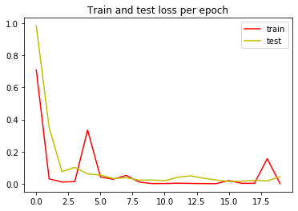

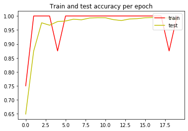

```python
network.show_epoch_performance()
```

20 layers:

```python
num_hidden_layers = 19
is_resnet=True
network = prepare_net_and_run(data_path, hidden_layers_size, num_hidden_layers, epochs, batch_size,  is_resnet=is_resnet)
```

```
shapes are X_train:(5, 25000), y_train:(25000, 5), X_val:(5, 6250), y_val:(6250, 5)
For epoch = 1, batch 0/782:
	 loss is 1.620927790113559 and accuracy is 15.625 percent.
For epoch = 1, batch 250/782:
	 loss is 1.5122379613404129 and accuracy is 31.25 percent.
For epoch = 1, batch 500/782:
	 loss is 1.2608387422719889 and accuracy is 50.0 percent.
For epoch = 1, batch 750/782:
	 loss is 0.6582643082379724 and accuracy is 75.0 percent.
For epoch = 2, batch 0/782:
	 loss is 0.8076188257443639 and accuracy is 62.5 percent.
For epoch = 2, batch 250/782:
	 loss is 1.0757922716395 and accuracy is 40.625 percent.
For epoch = 2, batch 500/782:
	 loss is 0.7393824465321789 and accuracy is 71.875 percent.
For epoch = 2, batch 750/782:
	 loss is 0.9064590507521213 and accuracy is 65.625 percent.
For epoch = 3, batch 0/782:
	 loss is 0.5321588174716301 and accuracy is 81.25 percent.
For epoch = 3, batch 250/782:
	 loss is 0.7844776239306449 and accuracy is 68.75 percent.
For epoch = 3, batch 500/782:
	 loss is 0.6159592112749044 and accuracy is 75.0 percent.
For epoch = 3, batch 750/782:
	 loss is 0.2479706435705634 and accuracy is 90.625 percent.
For epoch = 4, batch 0/782:
	 loss is 0.18806627335969975 and accuracy is 93.75 percent.
For epoch = 4, batch 250/782:
	 loss is 0.28191705293432645 and accuracy is 90.625 percent.
For epoch = 4, batch 500/782:
	 loss is 0.053775320455589706 and accuracy is 100.0 percent.
For epoch = 4, batch 750/782:
	 loss is 0.27303936902534975 and accuracy is 90.625 percent.
For epoch = 5, batch 0/782:
	 loss is 0.23218232452437174 and accuracy is 90.625 percent.
For epoch = 5, batch 250/782:
	 loss is 0.18245671531575222 and accuracy is 93.75 percent.
For epoch = 5, batch 500/782:
	 loss is 0.12606847665912602 and accuracy is 96.875 percent.
For epoch = 5, batch 750/782:
```

[output cut: 111 more lines]

```
For epoch = 19, batch 750/782:
	 loss is 0.17104429862939372 and accuracy is 96.875 percent.
For epoch = 20, batch 0/782:
	 loss is 0.003031151323091629 and accuracy is 100.0 percent.
For epoch = 20, batch 250/782:
	 loss is 0.1780522332539205 and accuracy is 96.875 percent.
For epoch = 20, batch 500/782:
	 loss is 0.01775748542122512 and accuracy is 100.0 percent.
For epoch = 20, batch 750/782:
	 loss is 0.0556503917784488 and accuracy is 96.875 percent.

########################################
For the test data:
Final loss for test data is 0.10823959743670039 and accuracy is 96.416 percent.
########################################
```

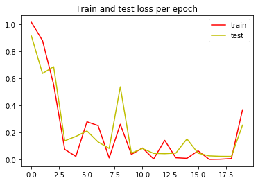

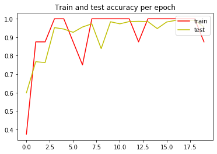

```python
network.show_epoch_performance()
```

## Using the PeaksData data:

We will now show the main results for all the above tests, this time using the PeaksData data. Question 2+3 above alraedy covered this data, so omitted from here.

### Qeustion 1:

Write code for computing the objective loss function “soft-max” and its gradient with respect to w and the biases. Make sure that the derivatives are correct using the gradient test. You should submit the results of the gradient test.

### Solution:

```
-----------  parameter = W ------------
Linear check should be 0.5 and is 4.84e-01
Linear check should be 0.5 and is 4.91e-01
Linear check should be 0.5 and is 4.96e-01
Linear check should be 0.5 and is 4.98e-01
Linear check should be 0.5 and is 4.99e-01
Linear check should be 0.5 and is 4.99e-01
Linear check should be 0.5 and is 5.00e-01
Linear check should be 0.5 and is 5.00e-01
Linear check should be 0.5 and is 5.00e-01
-----------------------------------------
Quadratic check should be 0.25 and is 2.60e-01
Quadratic check should be 0.25 and is 2.55e-01
Quadratic check should be 0.25 and is 2.52e-01
Quadratic check should be 0.25 and is 2.51e-01
Quadratic check should be 0.25 and is 2.51e-01
Quadratic check should be 0.25 and is 2.50e-01
Quadratic check should be 0.25 and is 2.50e-01
Quadratic check should be 0.25 and is 2.50e-01
Quadratic check should be 0.25 and is 2.50e-01
```

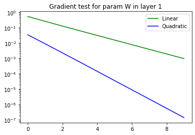

```
-----------  parameter = b ------------
Linear check should be 0.5 and is 5.62e-01
Linear check should be 0.5 and is 5.29e-01
Linear check should be 0.5 and is 5.14e-01
Linear check should be 0.5 and is 5.07e-01
Linear check should be 0.5 and is 5.03e-01
Linear check should be 0.5 and is 5.02e-01
Linear check should be 0.5 and is 5.01e-01
Linear check should be 0.5 and is 5.00e-01
Linear check should be 0.5 and is 5.00e-01
-----------------------------------------
Quadratic check should be 0.25 and is 2.56e-01
Quadratic check should be 0.25 and is 2.52e-01
Quadratic check should be 0.25 and is 2.51e-01
Quadratic check should be 0.25 and is 2.50e-01
Quadratic check should be 0.25 and is 2.50e-01
Quadratic check should be 0.25 and is 2.50e-01
Quadratic check should be 0.25 and is 2.50e-01
Quadratic check should be 0.25 and is 2.50e-01
Quadratic check should be 0.25 and is 2.50e-01
```

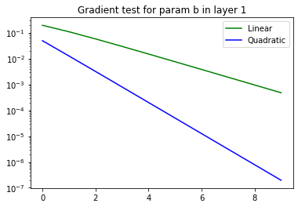

```python
data_name = 'PeaksData.mat'
data_path = 'data/'
data_path = data_path + data_name
gradient_test(test_type="softmax", is_res=False, data_path=data_path, iterations=10)
```

### Qeustion 4:

Write the code for the standard neural network. Including the forward pass and backward pass. Run gradient tests using the tanh activation function.

### Solution:

First we show the jacobian test for the weight and bias parameters of the tanh function:

```
---------------------------  param = W  ----------------------------
should be 0.5 and is 5.33e-01
should be 0.5 and is 5.09e-01
should be 0.5 and is 5.02e-01
should be 0.5 and is 5.00e-01
should be 0.5 and is 5.00e-01
should be 0.5 and is 5.00e-01
should be 0.5 and is 5.00e-01
should be 0.5 and is 5.00e-01
should be 0.5 and is 5.00e-01
should be 0.25 and is 1.78e-01
should be 0.25 and is 1.97e-01
should be 0.25 and is 2.22e-01
should be 0.25 and is 2.38e-01
should be 0.25 and is 2.45e-01
should be 0.25 and is 2.48e-01
should be 0.25 and is 2.49e-01
should be 0.25 and is 2.49e-01
should be 0.25 and is 2.50e-01
```

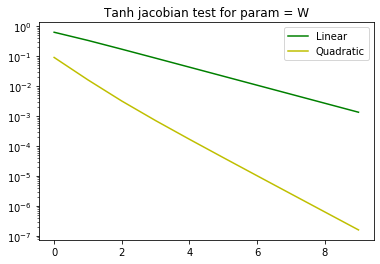

```
---------------------------  param = b  ----------------------------
should be 0.5 and is 5.21e-01
should be 0.5 and is 5.06e-01
should be 0.5 and is 5.02e-01
should be 0.5 and is 5.00e-01
should be 0.5 and is 5.00e-01
should be 0.5 and is 5.00e-01
should be 0.5 and is 5.00e-01
should be 0.5 and is 5.00e-01
should be 0.5 and is 5.00e-01
should be 0.25 and is 1.90e-01
should be 0.25 and is 2.14e-01
should be 0.25 and is 2.33e-01
should be 0.25 and is 2.42e-01
should be 0.25 and is 2.47e-01
should be 0.25 and is 2.48e-01
should be 0.25 and is 2.49e-01
should be 0.25 and is 2.50e-01
should be 0.25 and is 2.50e-01
```

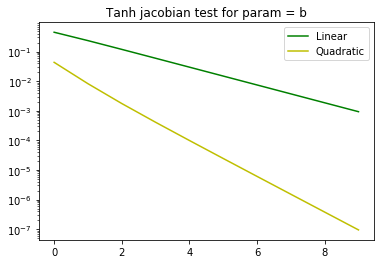

```python
jacobian_test(data_path=data_path)
```

#### Graient test:

For the gradient test we'll construct a short 2 layer network where the first layer's activation function is tanh and the second is the softmax function (which we already validated its correctness). For this simple network the hidden layer will contain 5 neurons (so the weight matrix w will be of shape (5, input_size)).  
We now show the gardient test for the tanh layer (later on we will show the classification results using the entire network):

```
-----------  parameter = W ------------
Linear check should be 0.5 and is 3.72e-01
Linear check should be 0.5 and is 4.00e-01
Linear check should be 0.5 and is 4.34e-01
Linear check should be 0.5 and is 4.62e-01
Linear check should be 0.5 and is 4.79e-01
Linear check should be 0.5 and is 4.89e-01
Linear check should be 0.5 and is 4.94e-01
Linear check should be 0.5 and is 4.97e-01
Linear check should be 0.5 and is 4.99e-01
-----------------------------------------
Quadratic check should be 0.25 and is 2.72e-01
Quadratic check should be 0.25 and is 2.57e-01
Quadratic check should be 0.25 and is 2.52e-01
Quadratic check should be 0.25 and is 2.51e-01
Quadratic check should be 0.25 and is 2.50e-01
Quadratic check should be 0.25 and is 2.50e-01
Quadratic check should be 0.25 and is 2.50e-01
Quadratic check should be 0.25 and is 2.50e-01
Quadratic check should be 0.25 and is 2.50e-01
```

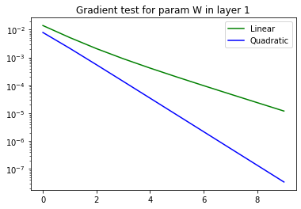

```
-----------  parameter = b ------------
Linear check should be 0.5 and is 5.23e-01
Linear check should be 0.5 and is 5.06e-01
Linear check should be 0.5 and is 5.02e-01
Linear check should be 0.5 and is 5.00e-01
Linear check should be 0.5 and is 5.00e-01
Linear check should be 0.5 and is 5.00e-01
Linear check should be 0.5 and is 5.00e-01
Linear check should be 0.5 and is 5.00e-01
Linear check should be 0.5 and is 5.00e-01
-----------------------------------------
Quadratic check should be 0.25 and is 1.41e-01
Quadratic check should be 0.25 and is 1.41e-01
Quadratic check should be 0.25 and is 1.50e-01
Quadratic check should be 0.25 and is 1.66e-01
Quadratic check should be 0.25 and is 1.87e-01
Quadratic check should be 0.25 and is 2.08e-01
Quadratic check should be 0.25 and is 2.25e-01
Quadratic check should be 0.25 and is 2.36e-01
Quadratic check should be 0.25 and is 2.43e-01
```

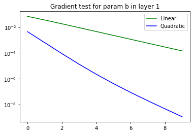

```python
gradient_test(test_type="tanh", is_res=False, data_path=data_path, iterations=10)
```

### Qeustion 5:

Repeat the previous section for the residual neural network.

### Solution:

```
---------------------------  param = W  ----------------------------
should be 0.5 and is 5.13e-01
should be 0.5 and is 5.01e-01
should be 0.5 and is 4.99e-01
should be 0.5 and is 4.99e-01
should be 0.5 and is 5.00e-01
should be 0.5 and is 5.00e-01
should be 0.5 and is 5.00e-01
should be 0.5 and is 5.00e-01
should be 0.5 and is 5.00e-01
should be 0.25 and is 2.95e-01
should be 0.25 and is 2.68e-01
should be 0.25 and is 2.58e-01
should be 0.25 and is 2.53e-01
should be 0.25 and is 2.52e-01
should be 0.25 and is 2.51e-01
should be 0.25 and is 2.50e-01
should be 0.25 and is 2.50e-01
should be 0.25 and is 2.50e-01
```

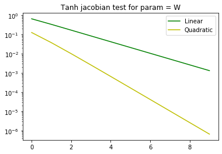

```
---------------------------  param = b  ----------------------------
should be 0.5 and is 5.13e-01
should be 0.5 and is 5.05e-01
should be 0.5 and is 5.02e-01
should be 0.5 and is 5.01e-01
should be 0.5 and is 5.00e-01
should be 0.5 and is 5.00e-01
should be 0.5 and is 5.00e-01
should be 0.5 and is 5.00e-01
should be 0.5 and is 5.00e-01
should be 0.25 and is 2.48e-01
should be 0.25 and is 2.51e-01
should be 0.25 and is 2.51e-01
should be 0.25 and is 2.51e-01
should be 0.25 and is 2.50e-01
should be 0.25 and is 2.50e-01
should be 0.25 and is 2.50e-01
should be 0.25 and is 2.50e-01
should be 0.25 and is 2.50e-01
```

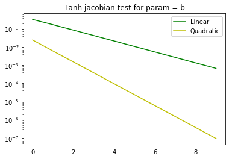

```python
jacobian_test(data_path=data_path, is_resnet=True)
```

```
-----------  parameter = W ------------
Linear check should be 0.5 and is 5.89e-01
Linear check should be 0.5 and is 5.23e-01
Linear check should be 0.5 and is 5.06e-01
Linear check should be 0.5 and is 5.02e-01
Linear check should be 0.5 and is 5.00e-01
Linear check should be 0.5 and is 5.00e-01
Linear check should be 0.5 and is 5.00e-01
Linear check should be 0.5 and is 5.00e-01
Linear check should be 0.5 and is 5.00e-01
-----------------------------------------
Quadratic check should be 0.25 and is 1.47e-01
Quadratic check should be 0.25 and is 1.35e-01
Quadratic check should be 0.25 and is 1.34e-01
Quadratic check should be 0.25 and is 1.39e-01
Quadratic check should be 0.25 and is 1.50e-01
Quadratic check should be 0.25 and is 1.67e-01
Quadratic check should be 0.25 and is 1.87e-01
Quadratic check should be 0.25 and is 2.08e-01
Quadratic check should be 0.25 and is 2.25e-01
```

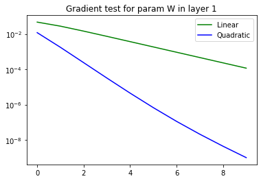

```
-----------  parameter = b ------------
Linear check should be 0.5 and is 5.15e-01
Linear check should be 0.5 and is 4.94e-01
Linear check should be 0.5 and is 4.93e-01
Linear check should be 0.5 and is 4.96e-01
Linear check should be 0.5 and is 4.98e-01
Linear check should be 0.5 and is 4.99e-01
Linear check should be 0.5 and is 4.99e-01
Linear check should be 0.5 and is 5.00e-01
Linear check should be 0.5 and is 5.00e-01
-----------------------------------------
Quadratic check should be 0.25 and is 1.69e+00
Quadratic check should be 0.25 and is 3.66e-01
Quadratic check should be 0.25 and is 2.88e-01
Quadratic check should be 0.25 and is 2.66e-01
Quadratic check should be 0.25 and is 2.57e-01
Quadratic check should be 0.25 and is 2.53e-01
Quadratic check should be 0.25 and is 2.52e-01
Quadratic check should be 0.25 and is 2.51e-01
Quadratic check should be 0.25 and is 2.50e-01
```

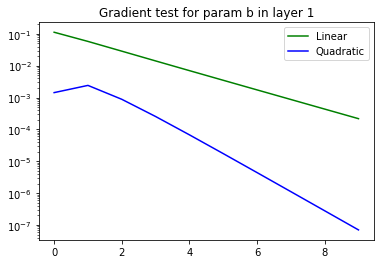

```
-----------  parameter = W2 ------------
Linear check should be 0.5 and is 4.93e-01
Linear check should be 0.5 and is 4.97e-01
Linear check should be 0.5 and is 4.98e-01
Linear check should be 0.5 and is 4.99e-01
Linear check should be 0.5 and is 5.00e-01
Linear check should be 0.5 and is 5.00e-01
Linear check should be 0.5 and is 5.00e-01
Linear check should be 0.5 and is 5.00e-01
Linear check should be 0.5 and is 5.00e-01
-----------------------------------------
Quadratic check should be 0.25 and is 2.50e-01
Quadratic check should be 0.25 and is 2.50e-01
Quadratic check should be 0.25 and is 2.50e-01
Quadratic check should be 0.25 and is 2.50e-01
Quadratic check should be 0.25 and is 2.50e-01
Quadratic check should be 0.25 and is 2.50e-01
Quadratic check should be 0.25 and is 2.50e-01
Quadratic check should be 0.25 and is 2.50e-01
Quadratic check should be 0.25 and is 2.50e-01
```

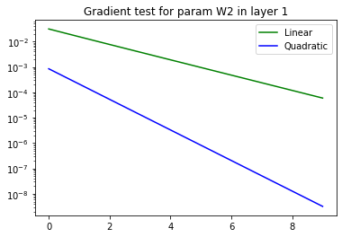

```python
gradient_test(test_type="tanh", is_res=True, data_path=data_path, iterations=10)
```

### Qeustion 6 + 7:

Compute a forward pass and a backward pass of a network with L layers (L is a parameter). See that the gradient of the whole network (softmax + layers) passes the gradient test. Submit this verification.  
Repeat section 3 for the entire network. Try a few network lengths and see how this influences the performance. Write your conclusions and demonstrate them.

### Solution:

```python
num_hidden_layers = 4

hidden_layers_size = 40
batch_size = 32
epochs = 20

network = prepare_net_and_run(data_path, hidden_layers_size, num_hidden_layers, epochs, batch_size)
```

```
shapes are X_train:(2, 25000), y_train:(25000, 5), X_val:(2, 6250), y_val:(6250, 5)
For epoch = 1, batch 0/782:
	 loss is 1.6071287451375458 and accuracy is 21.875 percent.
For epoch = 1, batch 250/782:
	 loss is 1.1654546733100686 and accuracy is 53.125 percent.
For epoch = 1, batch 500/782:
	 loss is 0.9938874480318101 and accuracy is 59.375 percent.
For epoch = 1, batch 750/782:
	 loss is 1.1781552242047424 and accuracy is 56.25 percent.
For epoch = 2, batch 0/782:
	 loss is 0.8609752014408929 and accuracy is 46.875 percent.
For epoch = 2, batch 250/782:
	 loss is 0.775439120556267 and accuracy is 78.125 percent.
For epoch = 2, batch 500/782:
	 loss is 0.6616676440536245 and accuracy is 68.75 percent.
For epoch = 2, batch 750/782:
	 loss is 0.6668420328939556 and accuracy is 75.0 percent.
For epoch = 3, batch 0/782:
	 loss is 0.7391332376290944 and accuracy is 62.5 percent.
For epoch = 3, batch 250/782:
	 loss is 0.4236815796831842 and accuracy is 90.625 percent.
For epoch = 3, batch 500/782:
	 loss is 0.5025832656796505 and accuracy is 78.125 percent.
For epoch = 3, batch 750/782:
	 loss is 0.46130819987136945 and accuracy is 84.375 percent.
For epoch = 4, batch 0/782:
	 loss is 0.7534387322916944 and accuracy is 71.875 percent.
For epoch = 4, batch 250/782:
	 loss is 0.5772502934928672 and accuracy is 71.875 percent.
For epoch = 4, batch 500/782:
	 loss is 0.2827667194703847 and accuracy is 93.75 percent.
For epoch = 4, batch 750/782:
	 loss is 0.3813270275162773 and accuracy is 87.5 percent.
For epoch = 5, batch 0/782:
	 loss is 0.2529638602730221 and accuracy is 93.75 percent.
For epoch = 5, batch 250/782:
	 loss is 0.35042681918227236 and accuracy is 84.375 percent.
For epoch = 5, batch 500/782:
	 loss is 0.3133642309731025 and accuracy is 87.5 percent.
For epoch = 5, batch 750/782:
```

[output cut: 111 more lines]

```
For epoch = 19, batch 750/782:
	 loss is 0.025039943992000307 and accuracy is 100.0 percent.
For epoch = 20, batch 0/782:
	 loss is 0.03811781904432383 and accuracy is 100.0 percent.
For epoch = 20, batch 250/782:
	 loss is 0.1324044677834793 and accuracy is 93.75 percent.
For epoch = 20, batch 500/782:
	 loss is 0.15109557237494436 and accuracy is 93.75 percent.
For epoch = 20, batch 750/782:
	 loss is 0.1543409818768031 and accuracy is 93.75 percent.

########################################
For the test data:
Final loss for test data is 0.06352183971631165 and accuracy is 97.776 percent.
########################################
```

Here are the graphs showing the accuracies and losses per epoch for the train and test sets:

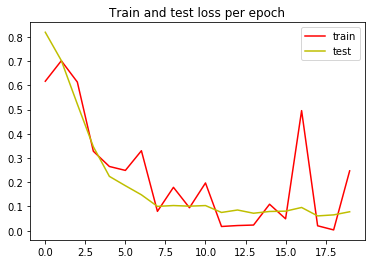

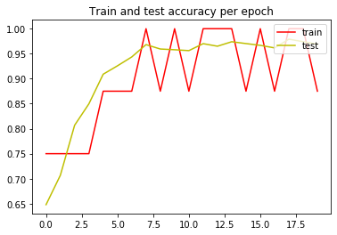

```python
network.show_epoch_performance()
```

Now we will show the gardients tests for parameters in the network's layers:

```
-----------  W  in layer 1 ------------
Linear check should be 0.5 and is 5.03e-01
Linear check should be 0.5 and is 5.01e-01
Linear check should be 0.5 and is 5.00e-01
Linear check should be 0.5 and is 5.00e-01
Linear check should be 0.5 and is 5.00e-01
Linear check should be 0.5 and is 5.00e-01
Linear check should be 0.5 and is 5.00e-01
Linear check should be 0.5 and is 5.00e-01
Linear check should be 0.5 and is 5.00e-01
-----------------------------------------
Quadratic check should be 0.25 and is 1.72e-01
Quadratic check should be 0.25 and is 1.88e-01
Quadratic check should be 0.25 and is 2.07e-01
Quadratic check should be 0.25 and is 2.24e-01
Quadratic check should be 0.25 and is 2.35e-01
Quadratic check should be 0.25 and is 2.42e-01
Quadratic check should be 0.25 and is 2.46e-01
Quadratic check should be 0.25 and is 2.48e-01
Quadratic check should be 0.25 and is 2.49e-01
```

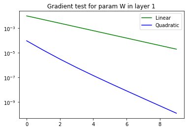

```
-----------  b  in layer 1 ------------
Linear check should be 0.5 and is 5.09e-01
Linear check should be 0.5 and is 5.02e-01
Linear check should be 0.5 and is 5.00e-01
Linear check should be 0.5 and is 5.00e-01
Linear check should be 0.5 and is 5.00e-01
Linear check should be 0.5 and is 5.00e-01
Linear check should be 0.5 and is 5.00e-01
Linear check should be 0.5 and is 5.00e-01
Linear check should be 0.5 and is 5.00e-01
-----------------------------------------
Quadratic check should be 0.25 and is 1.18e-01
Quadratic check should be 0.25 and is 9.15e-02
Quadratic check should be 0.25 and is 2.39e-02
Quadratic check should be 0.25 and is 9.54e-01
Quadratic check should be 0.25 and is 4.09e-01
Quadratic check should be 0.25 and is 2.99e-01
Quadratic check should be 0.25 and is 2.70e-01
Quadratic check should be 0.25 and is 2.59e-01
Quadratic check should be 0.25 and is 2.55e-01
```

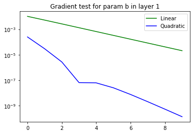

```
-----------  W  in layer 2 ------------
Linear check should be 0.5 and is 4.97e-01
Linear check should be 0.5 and is 4.98e-01
Linear check should be 0.5 and is 4.99e-01
Linear check should be 0.5 and is 5.00e-01
Linear check should be 0.5 and is 5.00e-01
Linear check should be 0.5 and is 5.00e-01
Linear check should be 0.5 and is 5.00e-01
Linear check should be 0.5 and is 5.00e-01
Linear check should be 0.5 and is 5.00e-01
-----------------------------------------
Quadratic check should be 0.25 and is 2.67e-01
Quadratic check should be 0.25 and is 2.58e-01
Quadratic check should be 0.25 and is 2.54e-01
Quadratic check should be 0.25 and is 2.52e-01
Quadratic check should be 0.25 and is 2.51e-01
Quadratic check should be 0.25 and is 2.50e-01
Quadratic check should be 0.25 and is 2.50e-01
Quadratic check should be 0.25 and is 2.50e-01
Quadratic check should be 0.25 and is 2.50e-01
```

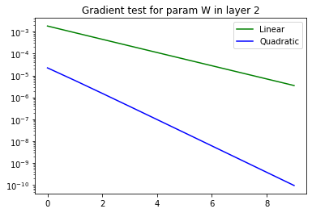

```
-----------  b  in layer 2 ------------
Linear check should be 0.5 and is 4.92e-01
Linear check should be 0.5 and is 4.93e-01
Linear check should be 0.5 and is 4.96e-01
Linear check should be 0.5 and is 4.98e-01
Linear check should be 0.5 and is 4.99e-01
Linear check should be 0.5 and is 4.99e-01
Linear check should be 0.5 and is 5.00e-01
Linear check should be 0.5 and is 5.00e-01
Linear check should be 0.5 and is 5.00e-01
-----------------------------------------
Quadratic check should be 0.25 and is 3.35e-01
Quadratic check should be 0.25 and is 2.80e-01
Quadratic check should be 0.25 and is 2.63e-01
Quadratic check should be 0.25 and is 2.56e-01
Quadratic check should be 0.25 and is 2.53e-01
Quadratic check should be 0.25 and is 2.51e-01
Quadratic check should be 0.25 and is 2.51e-01
Quadratic check should be 0.25 and is 2.50e-01
Quadratic check should be 0.25 and is 2.50e-01
```

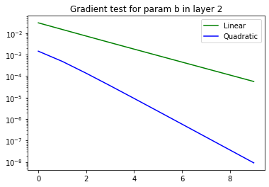

```
-----------  W  in layer 3 ------------
Linear check should be 0.5 and is 5.00e-01
Linear check should be 0.5 and is 5.00e-01
Linear check should be 0.5 and is 5.00e-01
Linear check should be 0.5 and is 5.00e-01
Linear check should be 0.5 and is 5.00e-01
Linear check should be 0.5 and is 5.00e-01
Linear check should be 0.5 and is 5.00e-01
Linear check should be 0.5 and is 5.00e-01
Linear check should be 0.5 and is 5.00e-01
-----------------------------------------
Quadratic check should be 0.25 and is 1.27e-01
Quadratic check should be 0.25 and is 1.29e-01
Quadratic check should be 0.25 and is 1.33e-01
Quadratic check should be 0.25 and is 1.40e-01
Quadratic check should be 0.25 and is 1.51e-01
Quadratic check should be 0.25 and is 1.69e-01
Quadratic check should be 0.25 and is 1.90e-01
Quadratic check should be 0.25 and is 2.10e-01
Quadratic check should be 0.25 and is 2.26e-01
```

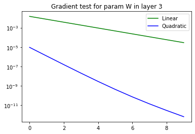

```
-----------  b  in layer 3 ------------
Linear check should be 0.5 and is 5.25e-01
Linear check should be 0.5 and is 5.10e-01
Linear check should be 0.5 and is 5.04e-01
Linear check should be 0.5 and is 5.02e-01
Linear check should be 0.5 and is 5.01e-01
Linear check should be 0.5 and is 5.00e-01
Linear check should be 0.5 and is 5.00e-01
Linear check should be 0.5 and is 5.00e-01
Linear check should be 0.5 and is 5.00e-01
-----------------------------------------
Quadratic check should be 0.25 and is 2.21e-01
Quadratic check should be 0.25 and is 2.27e-01
Quadratic check should be 0.25 and is 2.36e-01
Quadratic check should be 0.25 and is 2.42e-01
Quadratic check should be 0.25 and is 2.46e-01
Quadratic check should be 0.25 and is 2.48e-01
Quadratic check should be 0.25 and is 2.49e-01
Quadratic check should be 0.25 and is 2.49e-01
Quadratic check should be 0.25 and is 2.50e-01
```

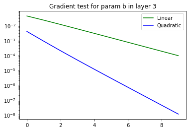

```
-----------  W  in layer 4 ------------
Linear check should be 0.5 and is 5.01e-01
Linear check should be 0.5 and is 5.01e-01
Linear check should be 0.5 and is 5.00e-01
Linear check should be 0.5 and is 5.00e-01
Linear check should be 0.5 and is 5.00e-01
Linear check should be 0.5 and is 5.00e-01
Linear check should be 0.5 and is 5.00e-01
Linear check should be 0.5 and is 5.00e-01
Linear check should be 0.5 and is 5.00e-01
-----------------------------------------
Quadratic check should be 0.25 and is 2.36e-01
Quadratic check should be 0.25 and is 2.42e-01
Quadratic check should be 0.25 and is 2.46e-01
Quadratic check should be 0.25 and is 2.48e-01
Quadratic check should be 0.25 and is 2.49e-01
Quadratic check should be 0.25 and is 2.49e-01
Quadratic check should be 0.25 and is 2.50e-01
Quadratic check should be 0.25 and is 2.50e-01
Quadratic check should be 0.25 and is 2.50e-01
```

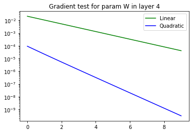

```
-----------  b  in layer 4 ------------
Linear check should be 0.5 and is 3.68e-01
Linear check should be 0.5 and is 4.11e-01
Linear check should be 0.5 and is 4.47e-01
Linear check should be 0.5 and is 4.71e-01
Linear check should be 0.5 and is 4.85e-01
Linear check should be 0.5 and is 4.92e-01
Linear check should be 0.5 and is 4.96e-01
Linear check should be 0.5 and is 4.98e-01
Linear check should be 0.5 and is 4.99e-01
-----------------------------------------
Quadratic check should be 0.25 and is 2.47e-01
Quadratic check should be 0.25 and is 2.46e-01
Quadratic check should be 0.25 and is 2.47e-01
Quadratic check should be 0.25 and is 2.48e-01
Quadratic check should be 0.25 and is 2.49e-01
Quadratic check should be 0.25 and is 2.50e-01
Quadratic check should be 0.25 and is 2.50e-01
Quadratic check should be 0.25 and is 2.50e-01
Quadratic check should be 0.25 and is 2.50e-01
```

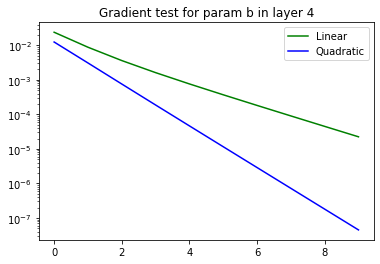

```
-----------  W  in layer 5 ------------
Linear check should be 0.5 and is 5.18e-01
Linear check should be 0.5 and is 5.09e-01
Linear check should be 0.5 and is 5.04e-01
Linear check should be 0.5 and is 5.02e-01
Linear check should be 0.5 and is 5.01e-01
Linear check should be 0.5 and is 5.01e-01
Linear check should be 0.5 and is 5.00e-01
Linear check should be 0.5 and is 5.00e-01
Linear check should be 0.5 and is 5.00e-01
-----------------------------------------
Quadratic check should be 0.25 and is 2.49e-01
Quadratic check should be 0.25 and is 2.50e-01
Quadratic check should be 0.25 and is 2.50e-01
Quadratic check should be 0.25 and is 2.50e-01
Quadratic check should be 0.25 and is 2.50e-01
Quadratic check should be 0.25 and is 2.50e-01
Quadratic check should be 0.25 and is 2.50e-01
Quadratic check should be 0.25 and is 2.50e-01
Quadratic check should be 0.25 and is 2.50e-01
```

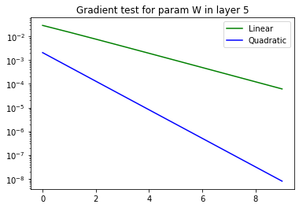

```
-----------  b  in layer 5 ------------
Linear check should be 0.5 and is 1.07e-01
Linear check should be 0.5 and is 3.56e-01
Linear check should be 0.5 and is 1.08e+00
Linear check should be 0.5 and is 6.31e-01
Linear check should be 0.5 and is 5.51e-01
Linear check should be 0.5 and is 5.23e-01
Linear check should be 0.5 and is 5.11e-01
Linear check should be 0.5 and is 5.05e-01
Linear check should be 0.5 and is 5.03e-01
-----------------------------------------
Quadratic check should be 0.25 and is 2.38e-01
Quadratic check should be 0.25 and is 2.43e-01
Quadratic check should be 0.25 and is 2.47e-01
Quadratic check should be 0.25 and is 2.48e-01
Quadratic check should be 0.25 and is 2.49e-01
Quadratic check should be 0.25 and is 2.50e-01
Quadratic check should be 0.25 and is 2.50e-01
Quadratic check should be 0.25 and is 2.50e-01
Quadratic check should be 0.25 and is 2.50e-01
```

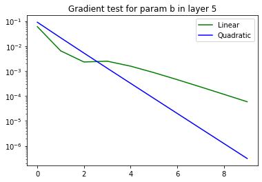

```python
gradient_test(test_type="network", is_res=False, data_path=data_path, iterations=10, num_hidden_layers=num_hidden_layers, hidden_layers_size=hidden_layers_size)
```

#### Very deep network performance

We will now show results for deeper networks. As we can see, deeper is not always better..

20 layers:

```python
num_hidden_layers = 19
network = prepare_net_and_run(data_path, hidden_layers_size, num_hidden_layers, epochs, batch_size)
```

```
shapes are X_train:(2, 25000), y_train:(25000, 5), X_val:(2, 6250), y_val:(6250, 5)
For epoch = 1, batch 0/782:
	 loss is 1.6070638961389938 and accuracy is 21.875 percent.
For epoch = 1, batch 250/782:
	 loss is 1.6109166950363976 and accuracy is 15.625 percent.
For epoch = 1, batch 500/782:
	 loss is 1.6078759991729799 and accuracy is 25.0 percent.
For epoch = 1, batch 750/782:
	 loss is 1.6061021465627332 and accuracy is 31.25 percent.
For epoch = 2, batch 0/782:
	 loss is 1.6066491265140586 and accuracy is 25.0 percent.
For epoch = 2, batch 250/782:
	 loss is 1.615098894312919 and accuracy is 9.375 percent.
For epoch = 2, batch 500/782:
	 loss is 1.6092468247871434 and accuracy is 31.25 percent.
For epoch = 2, batch 750/782:
	 loss is 1.609891206568442 and accuracy is 15.625 percent.
For epoch = 3, batch 0/782:
	 loss is 1.6072298649953207 and accuracy is 18.75 percent.
For epoch = 3, batch 250/782:
	 loss is 1.6232834114979207 and accuracy is 9.375 percent.
For epoch = 3, batch 500/782:
	 loss is 1.6105936944124135 and accuracy is 25.0 percent.
For epoch = 3, batch 750/782:
	 loss is 1.6150794989092254 and accuracy is 15.625 percent.
For epoch = 4, batch 0/782:
	 loss is 1.6054601109453788 and accuracy is 28.125 percent.
For epoch = 4, batch 250/782:
	 loss is 1.5991756248476967 and accuracy is 31.25 percent.
For epoch = 4, batch 500/782:
	 loss is 1.6207393170569298 and accuracy is 18.75 percent.
For epoch = 4, batch 750/782:
	 loss is 1.6185194112880397 and accuracy is 15.625 percent.
For epoch = 5, batch 0/782:
	 loss is 1.6053527350145997 and accuracy is 21.875 percent.
For epoch = 5, batch 250/782:
	 loss is 1.6110328516568062 and accuracy is 15.625 percent.
For epoch = 5, batch 500/782:
	 loss is 1.6077955497577563 and accuracy is 18.75 percent.
For epoch = 5, batch 750/782:
```

[output cut: 111 more lines]

```
For epoch = 19, batch 750/782:
	 loss is 1.6187734679189902 and accuracy is 12.5 percent.
For epoch = 20, batch 0/782:
	 loss is 1.6128565267995163 and accuracy is 18.75 percent.
For epoch = 20, batch 250/782:
	 loss is 1.6066542225737237 and accuracy is 18.75 percent.
For epoch = 20, batch 500/782:
	 loss is 1.6149313709119393 and accuracy is 6.25 percent.
For epoch = 20, batch 750/782:
	 loss is 1.6097650642290473 and accuracy is 25.0 percent.

########################################
For the test data:
Final loss for test data is 1.6098079003312864 and accuracy is 20.0 percent.
########################################
```

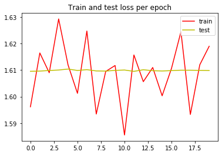

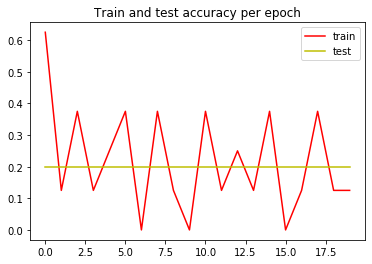

```python
network.show_epoch_performance()
```

### Qeustion 10:

If you opt to include the residual network in your code - compare between the optimization process of a standard network and a network that most of its steps are residual steps. Use about 10-20 steps in your network, and use similar vector sizes between the two options.

### Solution:

20 layers:

```python
num_hidden_layers = 19
is_resnet=True
network = prepare_net_and_run(data_path, hidden_layers_size, num_hidden_layers, epochs, batch_size,  is_resnet=is_resnet)
```

```
shapes are X_train:(2, 25000), y_train:(25000, 5), X_val:(2, 6250), y_val:(6250, 5)
For epoch = 1, batch 0/782:
	 loss is 1.5926225535245404 and accuracy is 15.625 percent.
For epoch = 1, batch 250/782:
	 loss is 1.2105743371386106 and accuracy is 53.125 percent.
For epoch = 1, batch 500/782:
	 loss is 0.9296918058990268 and accuracy is 59.375 percent.
For epoch = 1, batch 750/782:
	 loss is 1.0044676897122433 and accuracy is 65.625 percent.
For epoch = 2, batch 0/782:
	 loss is 0.5543163961776113 and accuracy is 78.125 percent.
For epoch = 2, batch 250/782:
	 loss is 1.0501353314841024 and accuracy is 59.375 percent.
For epoch = 2, batch 500/782:
	 loss is 0.6827126614631484 and accuracy is 65.625 percent.
For epoch = 2, batch 750/782:
	 loss is 0.8115707996099593 and accuracy is 75.0 percent.
For epoch = 3, batch 0/782:
	 loss is 0.5672456888695864 and accuracy is 78.125 percent.
For epoch = 3, batch 250/782:
	 loss is 0.49450353768032174 and accuracy is 84.375 percent.
For epoch = 3, batch 500/782:
	 loss is 0.7207410476695602 and accuracy is 78.125 percent.
For epoch = 3, batch 750/782:
	 loss is 0.37500399578767996 and accuracy is 87.5 percent.
For epoch = 4, batch 0/782:
	 loss is 0.30319642324774954 and accuracy is 96.875 percent.
For epoch = 4, batch 250/782:
	 loss is 0.5580505731383448 and accuracy is 71.875 percent.
For epoch = 4, batch 500/782:
	 loss is 0.3536698408152623 and accuracy is 84.375 percent.
For epoch = 4, batch 750/782:
	 loss is 0.6418034545535465 and accuracy is 78.125 percent.
For epoch = 5, batch 0/782:
	 loss is 0.240139074471517 and accuracy is 96.875 percent.
For epoch = 5, batch 250/782:
	 loss is 0.5468757222733474 and accuracy is 78.125 percent.
For epoch = 5, batch 500/782:
	 loss is 0.3875291076363382 and accuracy is 87.5 percent.
For epoch = 5, batch 750/782:
```

[output cut: 111 more lines]

```
For epoch = 19, batch 750/782:
	 loss is 0.4773330109651841 and accuracy is 81.25 percent.
For epoch = 20, batch 0/782:
	 loss is 0.09782973942626445 and accuracy is 96.875 percent.
For epoch = 20, batch 250/782:
	 loss is 0.4670867526482389 and accuracy is 75.0 percent.
For epoch = 20, batch 500/782:
	 loss is 0.124525665915526 and accuracy is 96.875 percent.
For epoch = 20, batch 750/782:
	 loss is 0.13576511408764436 and accuracy is 93.75 percent.

########################################
For the test data:
Final loss for test data is 0.12318766003307494 and accuracy is 96.272 percent.
########################################
```

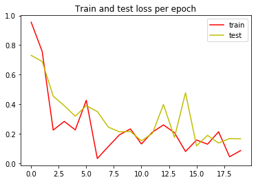

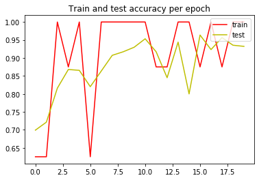

```python
network.show_epoch_performance()
```